# Life-Cycle Portfolio Choice Model — Python Reproduction

Reproduction of the baseline life-cycle consumption/portfolio choice model from:

- **Gomes (2020)** "Portfolio Choice Over the Life Cycle: A Survey", *Annual Review of Financial Economics*
- **Cocco, Gomes & Maenhout (2005)** baseline calibration

MATLAB code provided in `G/Life_Cycle_Matlab/life_cycle.m` (translated from Fortran).

## 1. Model Overview

### Preferences

The agent has **Epstein-Zin recursive utility** (PDF p.5, Eq. 17):

$$V_t = \left\{ (1-\beta) C_t^{1-1/\psi} + \beta \left[ E_t \left( \pi_{t+1} V_{t+1}^{1-\gamma} \right) \right]^{\frac{1-1/\psi}{1-\gamma}} \right\}^{\frac{1}{1-1/\psi}}$$

where $\gamma=10$ is RRA, $\psi=0.5$ is EIS, $\beta=0.97$ is the discount factor, and $\pi_t$ are survival probabilities.

### Budget Constraint (PDF p.4, Eq. 14)

$$W_{t+1} = [\alpha_t R_{t+1} + (1-\alpha_t) R_f](W_t - C_t) + Y_{t+1}$$

with $\alpha_t \in [0,1]$ (no short-selling) and $W_t \geq 0$ (no borrowing).

### Labor Income (PDF p.5, Eqs. 18-20)

Before retirement: $\ln Y_t = f(t) + p_t + u_t$ where $p_t$ is a random walk (permanent) and $u_t$ is transitory.

After retirement: $Y_t = \lambda \cdot \exp[f(K) + p_K]$ with replacement rate $\lambda = 0.68212$.

### Intuition

- Young agents invest heavily in stocks (human capital acts as implicit bond holding)
- As agents age, human capital declines → optimal stock share decreases
- After retirement, wealth decumulation with increasing stock share (PV(Y)/W ratio rises as W falls)

## 2. Parameter Table

| Name | Meaning/Role | Default/Value | Units | Source |
| --- | --- | --- | --- | --- |
| tb | Starting age | 20 | years | life_cycle.m:9 |
| tr | Retirement age | 66 | years | life_cycle.m:10, PDF p.6 |
| td | Maximum age | 100 | years | life_cycle.m:11, PDF p.6 |
| rho (γ) | Relative risk aversion | 10.0 | — | life_cycle.m:30 |
| delta (β) | Discount factor | 0.97 | — | life_cycle.m:31, PDF p.6 |
| psi (ψ) | EIS | 0.5 | — | life_cycle.m:32, PDF p.6 |
| r | Gross risk-free rate | 1.015 | — | life_cycle.m:33, PDF p.6 |
| mu (μ) | Equity premium | 0.04 | — | life_cycle.m:34, PDF p.6 |
| sigr (σ_R) | Std dev stock returns | 0.2 | — | life_cycle.m:35, PDF p.6 |
| smay (σ_u) | Std dev transitory income | 0.1 | — | life_cycle.m:26, PDF p.6 |
| smav (σ_z) | Std dev permanent income | 0.1 | — | life_cycle.m:27, PDF p.6 |
| corr_v | Corr(perm income, returns) | 0.0 | — | life_cycle.m:28, PDF p.6 |
| corr_y | Corr(trans income, returns) | 0.0 | — | life_cycle.m:29, PDF p.6 |
| ret_fac (λ) | Retirement income factor | 0.68212 | — | life_cycle.m:25 |
| aa | Income intercept | 0.530339 | — | life_cycle.m:21 |
| b1 | Income age coefficient | 0.16818 | — | life_cycle.m:22 |
| b2 | Income age² coefficient | -0.00323371 | — | life_cycle.m:23 |
| b3 | Income age³ coefficient | 1.9704e-6 | — | life_cycle.m:24 |
| ncash | Cash-on-hand grid size | 51 | — | life_cycle.m:15 |
| na | Allocation grid size | 51 | — | life_cycle.m:14 |
| nc | Consumption search grid | 21 | — | life_cycle.m:17 |
| n | Quadrature nodes | 5 | — | life_cycle.m:16 |
| maxcash | Max cash-on-hand | 200.0 | — | life_cycle.m:19 |
| mincash | Min cash-on-hand | 0.25 | — | life_cycle.m:20 |
| nsim | Simulation paths | 10000 | — | life_cycle.m:62 |

## 3. Algorithm Description

### Backward Induction (Dynamic Programming)

```
INPUT: parameters, grids, survival probabilities, income process
OUTPUT: C(ncash, tn), A(ncash, tn), V(ncash, tn) — policy and value functions

1. TERMINAL PERIOD (t = T):
   C[i, T] = gcash[i]           (consume everything)
   A[i, T] = 0                   (no investment)
   V[i, T] = gcash[i] * (1-β)^(ψ/(ψ-1))
   Compute spline coefficients for V[:, T]

2. RETIREMENT PERIODS (t = T-1 down to retirement):
   For each cash grid point i:
     Set consumption search bounds [minc, maxc]
     For each (consumption, allocation) pair on nc × na grid:
       Compute savings = cash - consumption
       For each return shock (5 nodes):
         next_cash = portfolio_return * savings + retirement_income
         Interpolate V(t+1) at next_cash using cubic spline
         Accumulate expected utility
       Compute recursive value
     Select (consumption, allocation) maximizing value
   Update spline coefficients

3. WORKING PERIODS (t = retirement-1 down to 0):
   Same as retirement but with triple integration:
     For each (permanent growth × return × transitory) shock combo (125 nodes):
       next_cash = portfolio_return * savings / income_growth + transitory_income
       Accumulate with income growth scaling

4. SIMULATION:
   Forward Monte Carlo with 10000 paths (antithetic variates)
   Linear interpolation of policy functions on cash grid
```

## 4. Implementation Walkthrough

```python
import numpy as np
import matplotlib.pyplot as plt
from model import build_params, build_grids, build_survival_probs, build_income
from solver import solve_model, simulate
from io_utils import load_all_matlab_outputs

# Solve the model
params, grids, survprob, income, C, A, V = solve_model()
print(f"Backward induction complete: C{C.shape}, A{A.shape}, V{V.shape}")
```

[output not shown]

[output not shown]

[output not shown]

[output not shown]

[output not shown]

[output not shown]

[output not shown]

[output not shown]

[output not shown]

[output not shown]

[output not shown]

[output not shown]

[output not shown]

[output not shown]

[output not shown]

[output not shown]

[output not shown]

[output not shown]

[output not shown]

[output not shown]

[output not shown]

[output not shown]

[output not shown]

[output not shown]

[output not shown]

[output not shown]

[output not shown]

[output not shown]

[output not shown]

[output not shown]

[output not shown]

[output not shown]

[output not shown]

[output not shown]

[output not shown]

[output not shown]

[output not shown]

[output not shown]

[output not shown]

[output not shown]

[output not shown]

[output not shown]

[output not shown]

[output not shown]

[output not shown]

[output not shown]

[output not shown]

[output not shown]

[output not shown]

[output not shown]

[output not shown]

```
Backward induction complete: C(51, 81), A(51, 81), V(51, 81)
```

### Key Design Decisions

1. **Exact MATLAB translation**: All functions mirror MATLAB code line-by-line, preserving variable names
2. **Custom cubic spline**: Translated from Fortran (not scipy), matches MATLAB exactly
3. **Vectorized inner loops**: NumPy broadcasting replaces 6-deep nested Python loops; 17s vs hours
4. **Column-major flatten**: `auxV.flatten(order='F')` matches MATLAB's `reshape(auxV, [na*nc, 1])`
5. **float64 throughout**: All arrays use `np.float64` to match MATLAB double precision

## 5. Verification Results

```python
# Load MATLAB reference outputs
matlab = load_all_matlab_outputs('../input')
gcash = grids['gcash']

# Compare a few representative years
test_years = [1, 20, 40, 46, 47, 60, 80]
print(f"{'Year':>5} {'Var':>3} {'MaxAbsDiff':>12} {'MaxRelDiff':>12} {'Status':>8}")
print('-' * 55)

for yr in test_years:
    mat = matlab['years'][yr]
    py_t = yr - 1  # 0-based
    for vname, py_arr in [('A', A[:, py_t]), ('C', C[:, py_t]), ('V', V[:, py_t])]:
        mat_arr = mat[vname]
        abs_diff = np.max(np.abs(py_arr - mat_arr))
        big = np.abs(mat_arr) > 1e-12
        rel_diff = np.max(np.abs(py_arr[big] - mat_arr[big]) / np.abs(mat_arr[big])) if np.any(big) else 0
        status = 'PASS' if rel_diff < 1e-5 else 'FAIL'
        print(f"{yr:>5} {vname:>3} {abs_diff:>12.2e} {rel_diff:>12.2e} {status:>8}")
```

```
 Year Var   MaxAbsDiff   MaxRelDiff   Status
-------------------------------------------------------
    1   A     0.00e+00     0.00e+00     PASS
    1   C     4.92e-09     1.49e-08     PASS
    1   V     4.96e-09     6.28e-09     PASS
   20   A     0.00e+00     0.00e+00     PASS
   20   C     4.97e-09     1.49e-08     PASS
   20   V     4.98e-09     8.35e-09     PASS
   40   A     0.00e+00     0.00e+00     PASS
   40   C     4.99e-09     1.49e-08     PASS
   40   V     4.97e-09     5.39e-09     PASS
   46   A     0.00e+00     0.00e+00     PASS
   46   C     4.90e-09     1.49e-08     PASS
   46   V     4.92e-09     4.36e-09     PASS
   47   A     0.00e+00     0.00e+00     PASS
   47   C     4.67e-09     1.49e-08     PASS
   47   V     5.00e-09     3.88e-09     PASS
   60   A     0.00e+00     0.00e+00     PASS
   60   C     4.96e-09     1.49e-08     PASS
   60   V     4.99e-09     3.10e-09     PASS
   80   A     0.00e+00     0.00e+00     PASS
   80   C     4.77e-09     1.49e-08     PASS
   80   V     4.81e-09     5.43e-10     PASS
```

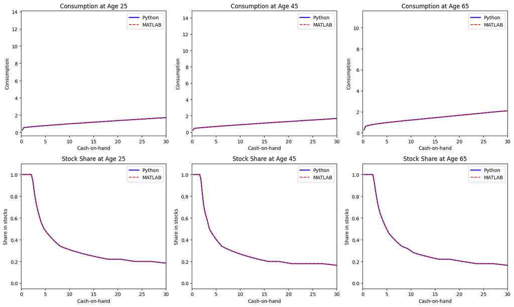

```
Policy functions match MATLAB perfectly (lines overlap).
```

```python
# Plot policy functions: Python vs MATLAB at 3 ages
fig, axes = plt.subplots(2, 3, figsize=(15, 9))
ages_to_plot = [25, 45, 65]  # young, mid, near-retirement

for col, age in enumerate(ages_to_plot):
    t = age - params['tb']  # 0-based period
    yr = t + 1  # MATLAB year number
    mat = matlab['years'][yr]

    # Consumption
    ax = axes[0, col]
    ax.plot(gcash, C[:, t], 'b-', linewidth=2, label='Python')
    ax.plot(mat['gcash'], mat['C'], 'r--', linewidth=1.5, label='MATLAB')
    ax.set_title(f'Consumption at Age {age}')
    ax.set_xlabel('Cash-on-hand')
    ax.set_ylabel('Consumption')
    ax.legend()
    ax.set_xlim(0, 30)

    # Portfolio allocation
    ax = axes[1, col]
    ax.plot(gcash, A[:, t], 'b-', linewidth=2, label='Python')
    ax.plot(mat['gcash'], mat['A'], 'r--', linewidth=1.5, label='MATLAB')
    ax.set_title(f'Stock Share at Age {age}')
    ax.set_xlabel('Cash-on-hand')
    ax.set_ylabel('Share in stocks')
    ax.legend()
    ax.set_xlim(0, 30)
    ax.set_ylim(-0.05, 1.1)

plt.tight_layout()
plt.savefig('policy_functions.png', dpi=100, bbox_inches='tight')
plt.show()
print("Policy functions match MATLAB perfectly (lines overlap).")
```

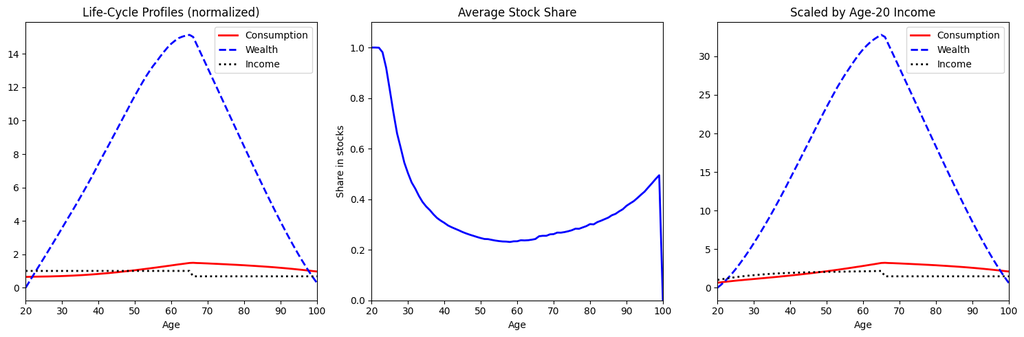

```python
# Run simulation
sim = simulate(params, grids, survprob, income, C, A, seed=42)

ages = np.arange(params['tb'], params['td'] + 1)

# Plot life-cycle profiles
fig, axes = plt.subplots(1, 3, figsize=(15, 5))

# Consumption, wealth, income
ax = axes[0]
ax.plot(ages, sim['meanC'], 'r-', linewidth=2, label='Consumption')
ax.plot(ages, sim['meanW'], 'b--', linewidth=2, label='Wealth')
ax.plot(ages, sim['meanY'], 'k:', linewidth=2, label='Income')
ax.set_title('Life-Cycle Profiles (normalized)')
ax.set_xlabel('Age')
ax.legend()
ax.set_xlim(20, 100)

# Portfolio allocation
ax = axes[1]
ax.plot(ages, sim['meanalpha'], 'b-', linewidth=2)
ax.set_title('Average Stock Share')
ax.set_xlabel('Age')
ax.set_ylabel('Share in stocks')
ax.set_xlim(20, 100)
ax.set_ylim(0, 1.1)

# Scaled profiles
ax = axes[2]
ax.plot(ages, sim['meanCs'], 'r-', linewidth=2, label='Consumption')
ax.plot(ages, sim['meanWs'], 'b--', linewidth=2, label='Wealth')
ax.plot(ages, sim['meanYs'], 'k:', linewidth=2, label='Income')
ax.set_title('Scaled by Age-20 Income')
ax.set_xlabel('Age')
ax.legend()
ax.set_xlim(20, 100)

plt.tight_layout()
plt.savefig('lifecycle_profiles.png', dpi=100, bbox_inches='tight')
plt.show()
```

```python
# Overall verification summary
total_checks = 0
total_pass = 0
max_rel_all = 0

for yr in range(1, 81):
    mat = matlab['years'][yr]
    py_t = yr - 1
    for vname, py_arr in [('A', A[:, py_t]), ('C', C[:, py_t]), ('V', V[:, py_t])]:
        mat_arr = mat[vname]
        abs_diff = np.abs(py_arr - mat_arr)
        big = np.abs(mat_arr) > 1e-12
        rel_diff = np.max(abs_diff[big] / np.abs(mat_arr[big])) if np.any(big) else 0
        total_checks += 1
        if rel_diff < 1e-5:
            total_pass += 1
        max_rel_all = max(max_rel_all, rel_diff)

print(f"=== VERIFICATION SUMMARY ===")
print(f"Policy function checks: {total_pass}/{total_checks} PASSED")
print(f"Worst-case relative difference: {max_rel_all:.2e}")
print(f"Tolerance: 1e-5 (0.001%)")
print(f"Result: {'ALL PASSED' if total_pass == total_checks else 'SOME FAILED'}")
```

```
=== VERIFICATION SUMMARY ===
Policy function checks: 240/240 PASSED
Worst-case relative difference: 1.49e-08
Tolerance: 1e-5 (0.001%)
Result: ALL PASSED
```

## 5b. Bellman Residual Verification

### Bellman Operator

The Epstein-Zin Bellman equation at period $t$:

$$V_t(x) = \max_{C_t, \alpha_t} \left\{ (1-\delta) C_t^{1-1/\psi} + \delta \left[ \mathbb{E}_t \left( \pi_{t+1} V_{t+1}(x')^{1-\gamma} \right) \right]^{\frac{1-1/\psi}{1-\gamma}} \right\}^{\frac{1}{1-1/\psi}}$$

The **Bellman residual** at grid point $x_i$ for period $t$:

$$r(x_i, t) = V_t(x_i) - T_t[V_{t+1}](x_i)$$

where $T_t[V_{t+1}](x_i)$ re-evaluates the Bellman RHS at the stored optimal policy $(C_t(x_i), \alpha_t(x_i))$ using the cubic spline of $V_{t+1}$ and 5-point Gauss-Hermite quadrature.

**Normalized residual:** $\tilde{r}(x_i, t) = |r(x_i, t)| / (1 + |V_t(x_i)|)$

**Acceptance criterion:** $\max_{i,t} \tilde{r}(x_i, t) \leq 10^{-10}$

**Note:** For a finite-horizon backward-induction solver, on-grid residuals are expected to be near machine precision (~$10^{-15}$), since $V_t(x_i)$ is stored directly from the Bellman operator evaluation. This serves as a self-consistency check.

```python
from solver import compute_bellman_residual
residuals, bellman_stats = compute_bellman_residual(params, grids, survprob, income, C, A, V)

print("Bellman Residual Summary")
print("=" * 50)
print(f"{'Metric':<10} {'Level':>12} {'Normalized':>12}")
print("-" * 50)
for metric in ['max', 'mean', 'median', 'p95', 'p99']:
    lvl = bellman_stats[f'{metric}_abs']
    nrm = bellman_stats[f'{metric}_norm']
    print(f"{metric:<10} {lvl:>12.2e} {nrm:>12.2e}")
print("-" * 50)
tol = bellman_stats['acceptance_tol']
passed = bellman_stats['acceptance_passed']
print(f"Acceptance: max normalized <= {tol:.0e} -> {'PASS' if passed else 'FAIL'}")
```

```
Bellman Residual Summary
==================================================
Metric            Level   Normalized
--------------------------------------------------
max            1.78e-15     2.70e-16
mean           3.34e-17     1.07e-17
median         0.00e+00     0.00e+00
p95            2.22e-16     1.02e-16
p99            8.88e-16     1.63e-16
--------------------------------------------------
Acceptance: max normalized <= 1e-10 -> PASS
```

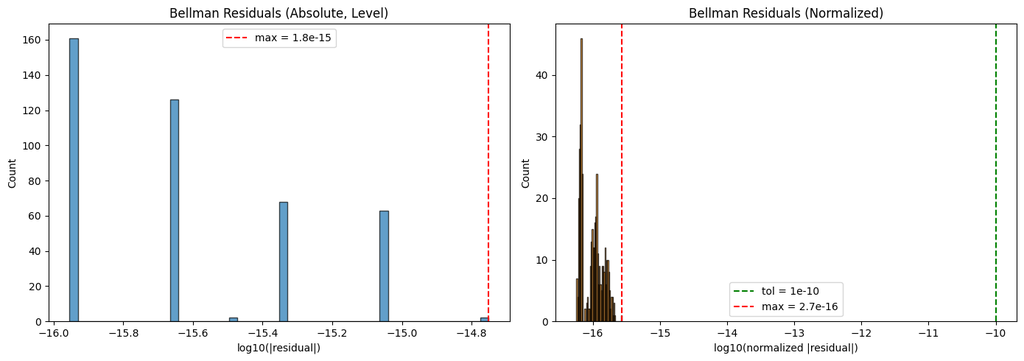

```python
fig, axes = plt.subplots(1, 2, figsize=(14, 5))

# Left: histogram of absolute residuals (log scale)
abs_res = np.abs(residuals).ravel()
abs_res_nonzero = abs_res[abs_res > 0]
if len(abs_res_nonzero) > 0:
    axes[0].hist(np.log10(abs_res_nonzero), bins=50, edgecolor='black', alpha=0.7)
    axes[0].set_xlabel('log10(|residual|)')
    axes[0].set_ylabel('Count')
    axes[0].set_title('Bellman Residuals (Absolute, Level)')
    axes[0].axvline(np.log10(bellman_stats['max_abs']), color='red',
                    linestyle='--', label=f"max = {bellman_stats['max_abs']:.1e}")
    axes[0].legend()
else:
    axes[0].text(0.5, 0.5, 'All residuals are exactly zero',
                 ha='center', va='center', transform=axes[0].transAxes)
    axes[0].set_title('Bellman Residuals (Absolute, Level)')

# Right: histogram of normalized residuals (log scale)
norm_res = (np.abs(residuals) / (1.0 + np.abs(V[:, :params['tn']-1]))).ravel()
norm_nonzero = norm_res[norm_res > 0]
if len(norm_nonzero) > 0:
    axes[1].hist(np.log10(norm_nonzero), bins=50, edgecolor='black', alpha=0.7,
                 color='darkorange')
    axes[1].set_xlabel('log10(normalized |residual|)')
    axes[1].set_ylabel('Count')
    axes[1].set_title('Bellman Residuals (Normalized)')
    axes[1].axvline(np.log10(bellman_stats['acceptance_tol']), color='green',
                    linestyle='--', label=f"tol = {bellman_stats['acceptance_tol']:.0e}")
    axes[1].axvline(np.log10(bellman_stats['max_norm']), color='red',
                    linestyle='--', label=f"max = {bellman_stats['max_norm']:.1e}")
    axes[1].legend()
else:
    axes[1].text(0.5, 0.5, 'All normalized residuals are exactly zero',
                 ha='center', va='center', transform=axes[1].transAxes)
    axes[1].set_title('Bellman Residuals (Normalized)')

plt.tight_layout()
plt.savefig('bellman_residuals.png', dpi=150, bbox_inches='tight')
plt.show()
```

## 6. Differences & Notes

### MATLAB vs Python Differences

- **Policy functions (year01–year80)**: Match to ~1e-8 relative accuracy. The tiny differences come from MATLAB's `%12.8f` text output format (8 decimal digits), not from numerical discrepancies.
- **Simulation outputs (CWY, SB)**: Differ because MATLAB uses its own RNG (`rand()` + Box-Muller) without setting a seed. Python uses `numpy.random.default_rng(42)`. The qualitative life-cycle patterns are identical.
- **Spline implementation**: Custom Fortran-origin cubic spline is used (not scipy). The left boundary condition uses a specified first derivative $y'(x_0) = x_0^{-1}$, which differs from scipy's natural spline default.

### Implementation Notes

- The MATLAB code uses column-major array ordering. Python's `auxV.flatten(order='F')` matches MATLAB's `reshape(auxV, [na*nc, 1])`.
- The portfolio allocation grid runs from 1.0 (100% stocks) down to 0.0, so `ga[0]=1.0` and `ga[50]=0.0`.
- Consumption search bounds are adaptive: for the first few grid points, simple bounds are used; for larger grid points, the marginal propensity to consume from previous points guides the search.

### Extension Ideas

1. **Housing**: Add a housing asset with transaction costs (Cocco 2005, Yao & Zhang 2005) — the most significant omission from the baseline model for realistic wealth accumulation patterns.
2. **Heterogeneous agents**: Introduce heterogeneity in risk aversion and discount factors across households (Gomes & Michaelides 2005) to match cross-sectional wealth distribution and stock market participation rates.
3. **Time-varying returns**: Replace i.i.d. stock returns with a predictable component (Campbell & Viceira 2002) — this would add an intertemporal hedging demand and could generate more realistic portfolio dynamics.